# Ask or Delegate? How the World Uses AI Differently

Model report 3 — Diversity in a Globalized World

Author

Popescu (example report)

Published

September 12, 2026

```r
library(sf)
library(ggplot2)

countries <- readRDS("data/ai/preprocessed_data/countries.rds")
```

# Introduction

A trade shock arrives in a place whether anyone wants it or not; nobody in a town chooses to have its factory close. Most of what this course studies works that way. AI is different. It arrives as a website, open to anyone with a connection, and each person who uses it decides what to ask for. The question is therefore not only where AI reaches, but what people do with it once it does.

The obvious guess is that AI is used the same way everywhere, since the tool is identical: the same model, the same interface, the same price. But a tool is also defined by its users. Where most users are students it may serve one purpose; where most are professionals, another. We therefore expected purposes to differ even though the technology does not.

**This report asks whether AI is used the same way everywhere.**

# Data

Anthropic, which makes the AI assistant Claude, classified millions of anonymised conversations and published country-level totals. We use May 2026, for which 121 countries have data. Each row is one country. Table 1 shows four of them.

```r
countries |>
  st_drop_geometry() |>
  subset(iso3 %in% c("MEX", "USA", "TUN", "NOR"),
         select = c(country, adoption_rate, used_for_study, automation_style)) |>
  knitr::kable(row.names = FALSE)
```

Table 1: Four countries from the data (all values in %).

| country | adoption_rate | used_for_study | automation_style |
| --- | --- | --- | --- |
| United States of America | 20.16 | 8.94 | 49.59 |
| Tunisia | 0.27 | 51.52 | 49.79 |
| Norway | 0.35 | 26.38 | 41.26 |
| Mexico | 1.32 | 21.08 | 50.36 |

Three variables matter here. `used_for_study` is the share of a country’s conversations that are coursework. `automation_style` is the share in which the user handed over a whole task rather than working through it with the model. `adoption_rate` is the country’s share of all Claude use in the world: about 20% for the United States and 0.3% for Tunisia. Despite its name, it is not adjusted for population, so large countries tend to score high.

One warning applies to everything that follows, and we return to it at the end: the data describes **people who use Claude**, not the population of a country.

# Findings

## What AI is used for

Figure 1 maps the share of use that is coursework. It is highest in North Africa, the Andes, southern Africa and Indonesia: more than half of all use in Tunisia, and close to half in Algeria and Indonesia. In the United States and Canada it is under one in ten, and Mexico sits at about 21%. Grey countries have no data, a reminder that Claude is not used everywhere.

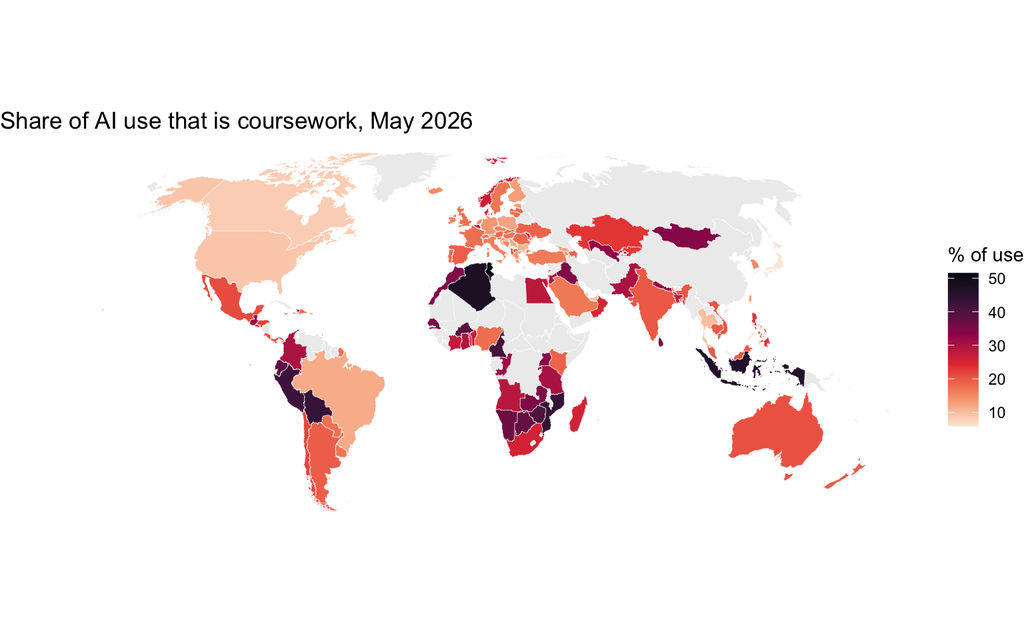

Figure 1: Share of Claude use that is coursework, by country, May 2026.

```r
ggplot(countries) +
  geom_sf(aes(fill = used_for_study), color = "white", linewidth = 0.1) +
  scale_fill_viridis_c(option = "rocket", direction = -1, na.value = "grey93",
                       name = "% of use") +
  labs(title = "Share of AI use that is coursework, May 2026") +
  coord_sf(crs = "+proj=robin") +
  theme_void()
```

## How AI is used

Figure 2 asks not what AI is used for but how: the share of use in which the whole task is handed over. Many of the countries that use AI most for coursework also delegate most.

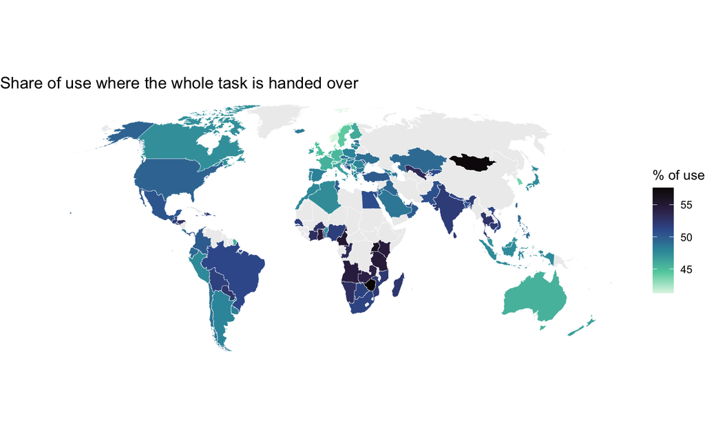

Figure 2: Share of Claude use in which the whole task is handed over, by country, May 2026.

```r
ggplot(countries) +
  geom_sf(aes(fill = automation_style), color = "white", linewidth = 0.1) +
  scale_fill_viridis_c(option = "mako", direction = -1, na.value = "grey93",
                       name = "% of use") +
  labs(title = "Share of use where the whole task is handed over") +
  coord_sf(crs = "+proj=robin") +
  theme_void()
```

## Where the use comes from

Figure 3 shows each country’s share of all Claude use. It largely reflects how big a country is: the United States alone accounts for a fifth of the total and India for 7%. The countries that study most, such as Tunisia and Mozambique, and those that delegate most, such as Zimbabwe, each account for well under 1%.

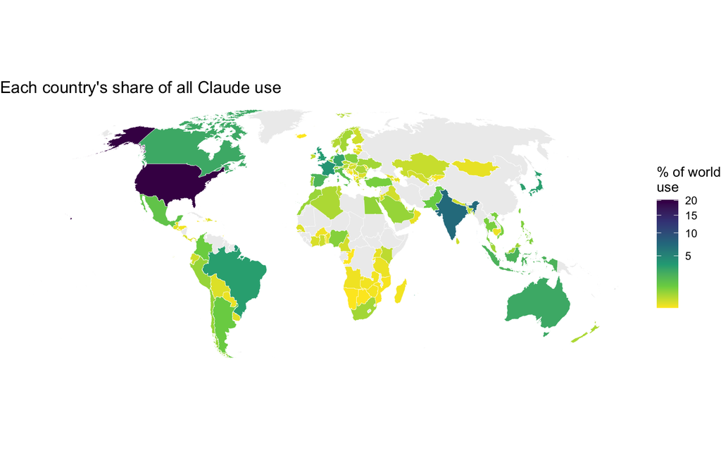

Figure 3: Each country’s share of all Claude use, May 2026 (square-root colour scale).

```r
ggplot(countries) +
  geom_sf(aes(fill = adoption_rate), color = "white", linewidth = 0.1) +
  scale_fill_viridis_c(option = "viridis", direction = -1, trans = "sqrt",
                       na.value = "grey93", name = "% of world\nuse") +
  labs(title = "Each country's share of all Claude use") +
  coord_sf(crs = "+proj=robin") +
  theme_void()
```

## Studying and delegating together

Figure 4 plots the two purposes against each other, one dot per country. The line slopes upward, with a correlation of 0.40: countries where more use is coursework also tend to be countries where more use hands over the whole task.

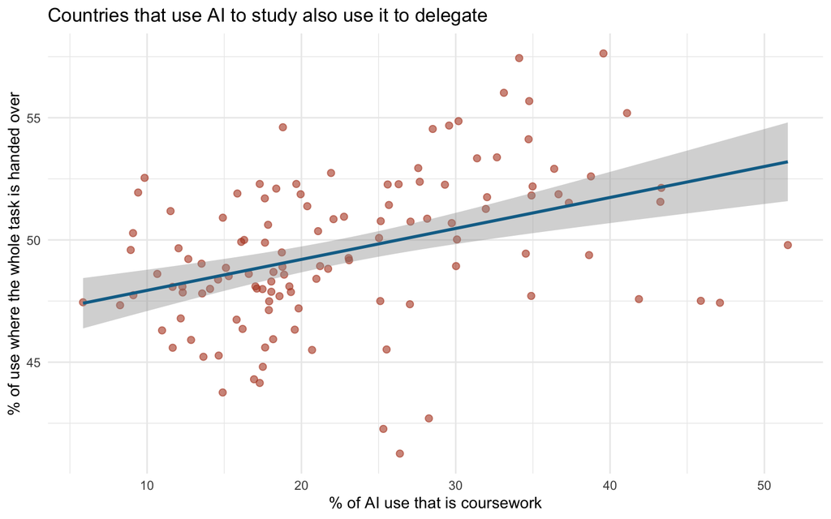

Figure 4: Coursework and delegation across 121 countries, May 2026.

```r
ggplot(countries, aes(x = used_for_study, y = automation_style)) +
  geom_point(alpha = 0.6, size = 2, color = "#b44527") +
  geom_smooth(method = "lm", color = "#0f6f96") +
  labs(title = "Countries that use AI to study also use it to delegate",
       x = "% of AI use that is coursework",
       y = "% of use where the whole task is handed over") +
  theme_minimal()
```

This is a pattern across countries, not across people. It does not show that students are the ones delegating, only that countries with more coursework use also have more delegation. The tempting reading, that students use AI to get answers rather than explanations, is exactly the claim this data cannot support.

## Is the pattern the same in large and small shares of use?

A natural next question is whether countries delegate less as AI becomes established. This data cannot answer that directly, because a country’s share of world use rises with its population as much as with how widely AI is used within it. We can, however, check whether the relationship looks different in countries with small and large shares. Figure 5 splits the countries into four groups of roughly equal size on that measure.

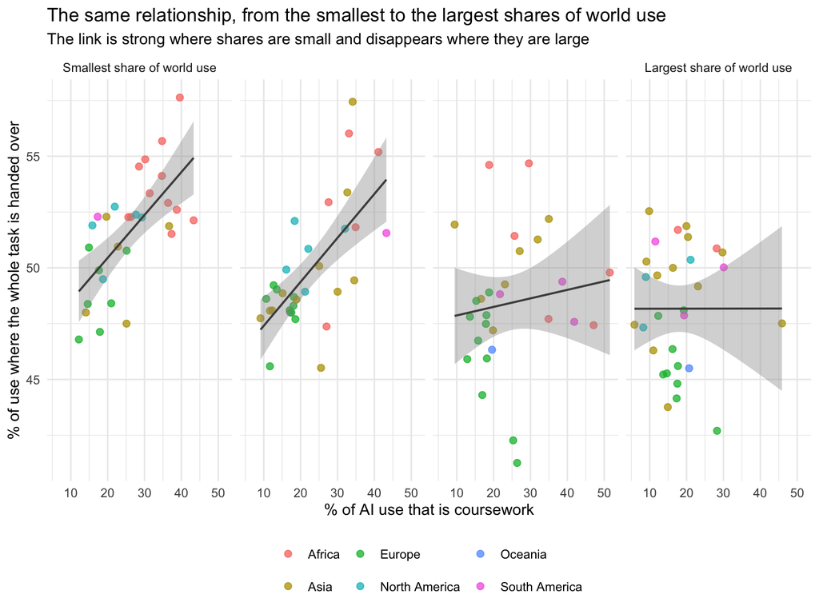

Figure 5: Coursework and delegation, in four groups of countries ordered by share of world use.

```r
d <- st_drop_geometry(countries)
d <- d[!is.na(d$used_for_study) & d$continent != "Seven seas (open ocean)", ]
d$share_group <- cut(d$adoption_rate,
                     breaks = quantile(d$adoption_rate, c(0, .25, .5, .75, 1)),
                     labels = c("Smallest share of world use", "", " ",
                                "Largest share of world use"),
                     include.lowest = TRUE)

ggplot(d, aes(x = used_for_study, y = automation_style)) +
  geom_point(aes(color = continent), alpha = 0.75, size = 2) +
  geom_smooth(method = "lm", color = "grey30", linewidth = 0.7) +
  facet_wrap(~ share_group, nrow = 1) +
  labs(title = "The same relationship, from the smallest to the largest shares of world use",
       subtitle = "The link is strong where shares are small and disappears where they are large",
       x = "% of AI use that is coursework",
       y = "% of use where the whole task is handed over",
       color = NULL) +
  theme_minimal() +
  theme(legend.position = "bottom")
```

The answer is no. Among the countries with the smallest shares of world use, coursework and delegation are closely linked, with a correlation of 0.66 in each of the two lower groups. Among the countries with the largest shares, the link disappears: 0.13 in the third group and 0.00 in the top one, which includes the United States, India, Germany and Mexico. The overall correlation of 0.40 in Figure 4 therefore comes almost entirely from countries with small shares. The largest-share countries also sit somewhat lower and further left. On average, 48% of their use hands over the whole task and 18% is coursework, against 52% and 26% in the smallest-share group.

# Discussion

AI is not used the same way everywhere. The tool is identical, but what it is used for varies widely across countries. That makes this a finding about societies rather than about technology.

Coursework and delegation go together, but only among countries that account for small shares of world use. Among those with the largest shares, a mixed group that includes India and Nigeria as well as Germany and Singapore, the two are unrelated and delegation is somewhat lower.

We cannot say why. Countries with large shares tend to be bigger, and many are richer with older populations. Any of these could produce the pattern, as could longer experience with AI. And because we observe many countries in a single month, we cannot watch any country change over time.

The maps did something the scatterplots could not. Seeing the same regions darken in Figure 1 and Figure 2 is what suggested comparing the two. Figure 3 is what showed us that the share-of-use measure largely tracks country size.

# Limitations

The most important limitation affects every sentence above: the data describes Claude users, not populations. Only a fraction of any country’s people use Claude, so “half of Tunisian use is coursework” describes Tunisian Claude users. They are probably younger, more urban and better connected than Tunisians in general. When we write “in country X, people use AI for…”, we mean the people in country X who use Claude.

The patterns are between countries, not individuals. And `adoption_rate` measures a country’s share of world use, not how widespread AI is within it. Asking whether use changes as AI spreads would need a measure adjusted for population.

The data covers one assistant in one month. Users of other AI tools may behave differently, and May 2026 may not be typical. Finally, “delegating” is a classification, not a judgement: handing over a whole task is sometimes exactly the right use of the tool.

# How we used AI

| What we did | AI? | What we asked | How we checked |
| --- | --- | --- | --- |
| Fixing missing countries | Yes | Why France and Norway were blank on our map | Found the country-code column was `-99`; checked against the data |
| Choosing a map projection | Yes | How to avoid Greenland dominating | Compared three projections and chose Robinson |
| Deciding the question | No | — | — |
| Writing the interpretation | No | — | — |

**One prompt we used:**

> “I have an sf object called `countries` with a variable `adoption_rate` that is very skewed. My map is almost entirely one colour. What are my options and what does each one do to the reader’s impression?”

**What we changed afterwards.** It suggested three fixes and we chose the square root scale. But its last point was the useful one: any transformation changes what the reader sees, so we should say which one we used. That is why `trans = "sqrt"` is visible in the code above rather than hidden.

# Where the data comes from

Anthropic Economic Index, release of 26 June 2026, published under a CC-BY licence at https://huggingface.co/datasets/Anthropic/EconomicIndex. Country outlines from Natural Earth.